# Present values and loan-corrected demand elasticities

```r
library(dplyr)
library(ggplot2)
library(tidyr)
library(readxl)
library(WDI)
library(countrycode)
library(stargazer)
library(ggrepel)
library(broom)
library(sandwich)
library(lmtest)

## Every regression in this file is reported with HC1 robust inference.
robust_se <- function(model) sqrt(diag(vcovHC(model, type = "HC1")))
robust_p <- function(model) {
  coeftest(model, vcov. = vcovHC(model, type = "HC1"))[, "Pr(>|t|)"]
}

robust_tidy <- function(model, conf.int = TRUE) {
  ## Built directly off the coeftest/coefci matrices rather than routed
  ## through broom::tidy(). broom does not document a tidy method for
  ## class "coeftest", so leaning on S3 dispatch there is a real risk of
  ## either an error or a wrong column shape landing quietly downstream.
  ## coeftest()'s column names ("Estimate", "Std. Error", "t value",
  ## "Pr(>|t|)") are stable lmtest output, safe to index on directly.
  ct <- coeftest(model, vcov. = vcovHC(model, type = "HC1"))
  out <- data.frame(
    term      = rownames(ct),
    estimate  = ct[, "Estimate"],
    std.error = ct[, "Std. Error"],
    statistic = ct[, "t value"],
    p.value   = ct[, "Pr(>|t|)"],
    row.names = NULL,
    stringsAsFactors = FALSE
  )
  if (conf.int) {
    ci <- coefci(model, vcov. = vcovHC(model, type = "HC1"))
    out$conf.low  <- ci[, 1]
    out$conf.high <- ci[, 2]
  }
  out
}
```

```r
## Moved up from just before "Publication figures" (used to be defined for
## the first time after other-correlations, but calib-sweep-plot and
## placebo-plot both call it well before that point). Defining it here,
## right after setup, means every later chunk can use it and nothing that
## runs earlier than its old definition can break on a fresh knit.
theme_eer <- function(base_size = 12) {
  theme_classic(base_size = base_size) +
    theme(
      text             = element_text(colour = "grey15"),
      plot.title       = element_text(size = base_size + 1, face = "plain"),
      plot.subtitle    = element_text(size = base_size - 1, colour = "grey35"),
      plot.caption     = element_text(size = base_size - 3, colour = "grey40",
                                      hjust = 0, margin = margin(t = 8)),
      axis.line          = element_line(colour = "grey20", linewidth = 0.4),
      axis.ticks         = element_line(colour = "grey20", linewidth = 0.4),
      panel.grid.major.y = element_line(colour = "grey92", linewidth = 0.3),
      legend.position    = "bottom",
      legend.key.width   = unit(1.4, "lines")
    )
}

accent <- "#1F4E79"   # one muted navy accent, prints cleanly in greyscale
```

```r
# Prices and conversion
L          <- 9250      # one year of tuition (loan principal), GBP
Ppost      <- 22200     # post-reform headline fee, GBP
eur_gbp    <- 0.85      # EUR -> GBP conversion,

#see https://www.exchangerates.org.uk/EUR-GBP-spot-exchange-rates-history-2024.html

# Homogeneous log price change used for the "equal k" benchmark.
## FIX 1: this used to be the literal 0.86 (the FX rate). It should be the
## naive log fee change. log(22200) - log(9250) = 0.8755

k_common   <- log(Ppost) - log(L)   # about 0.8755

# Illustrative pooled elasticity for the aggregate section.

beta_pooled <- -1.109

# Loan repayment parameters (UK ICR plan)
loan_alpha <- 0.09      # repayment rate above threshold
loan_tau   <- 27295     # repayment threshold, GBP
loan_g     <- 0.02      # nominal wage growth
loan_r     <- 0.03      # discount rate
loan_T     <- 30        # repayment horizon, years
```

# On aggregate level

We use the following equation:

$$B_0=L,\qquad
R_t=\min\left\{\alpha\max\left[0,Y_0(1+g)^{t-1}-\tau\right],B_{t-1}\right\},
\qquad B_t=B_{t-1}-R_t,$$

$$PV_{loan}=\max\left\{1,\sum_{t=1}^T\frac{R_t}{(1+r)^t}\right\}.$$

hence $k$ is calculated with the following assumptions:

$$\Delta \log(P_i)=\log(22200)-\log(PV_{loan,i}).$$

where $Y_i$ is the starting salary in country $i$.

```r
# Present value of repayments. Payments stop once the loan is repaid.
# horizon replaces the old argument name T, which shadows R's TRUE.
pv_loan <- function(Y0,
                    L     = 9250,
                    alpha = 0.09,
                    tau   = 27295,
                    g     = 0.02,
                    r     = 0.03,
                    horizon = 30,
                    floor_pv = TRUE) {

  balance <- L
  pv      <- 0

  for (t in 1:horizon) {
    Yt      <- Y0 * (1 + g)^(t - 1)          # income path
    Rt      <- alpha * max(0, Yt - tau)      # repayment rule
    payment <- min(Rt, balance)             # cannot exceed remaining balance
    pv      <- pv + payment / (1 + r)^t      # discounted payment
    balance <- balance - payment
    if (balance <= 0) break                  # stop once repaid
  }

  # floor at 1 to avoid log(0) downstream for very low incomes
  if (floor_pv) pv <- max(pv, 1)
  pv
}

# convenience wrapper carrying the params from the setup chunk
pv_of <- function(Y0) {
  pv_loan(Y0, L = L, alpha = loan_alpha, tau = loan_tau,
          g = loan_g, r = loan_r, horizon = loan_T)
}
```

```r
# Implied elasticity from a present value, given the illustrative pooled beta.
# Signed elasticity eta = beta / k, with k = log(Ppost) - log(PV).
elasticity_from_income <- function(Y0) {
  PV  <- pv_of(Y0)
  k   <- log(Ppost) - log(PV)
  eta <- beta_pooled / k
  c(PV = PV, k = k, elasticity = eta)
}
```

```r
## FIX: the original salary vector repeated 32000 and 42000. De-duplicated here.
salary_levels <- c(20000, 26000, 32000, 35000, 42000, 50000)

results <- t(sapply(salary_levels, elasticity_from_income))

table_results <- data.frame(
  Starting_Salary = salary_levels,
  PV_Loan         = round(results[, "PV"], 2),
  k               = round(results[, "k"], 3),
  Elasticity      = round(results[, "elasticity"], 3)
)

table_results
```

| Starting_Salary | PV_Loan | k | Elasticity |
| --- | --- | --- | --- |
| 20000 | 2366.69 | 2.239 | -0.495 |
| 26000 | 5835.48 | 1.336 | -0.830 |
| 32000 | 7435.25 | 1.094 | -1.014 |
| 35000 | 7822.44 | 1.043 | -1.063 |
| 42000 | 8301.81 | 0.984 | -1.127 |
| 50000 | 8547.92 | 0.954 | -1.162 |

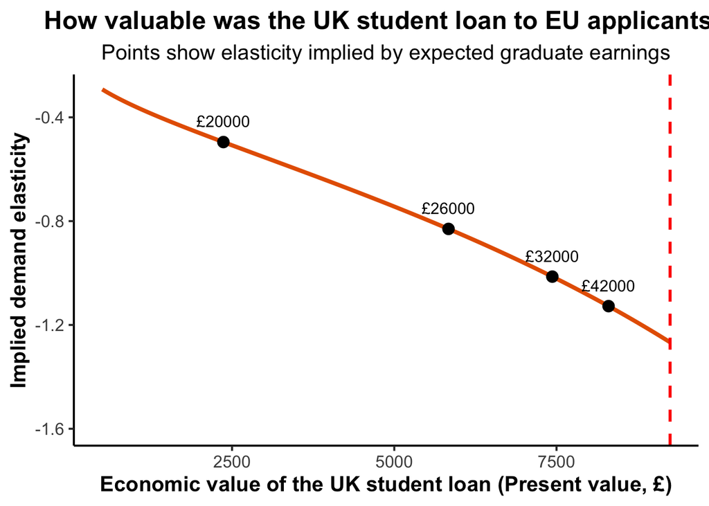

```r
# elasticity as a function of the loan's present value
PV_grid  <- seq(500, 9250, by = 50)
curve_df <- data.frame(
  PV = PV_grid,
  elasticity = beta_pooled / (log(Ppost) - log(PV_grid))
)

# representative income groups marked on the curve
salary_points <- c(20000, 26000, 32000, 42000)
salary_df <- data.frame(salary = salary_points,
                        PV = sapply(salary_points, pv_of))
salary_df$elasticity <- beta_pooled / (log(Ppost) - log(salary_df$PV))

ggplot(curve_df, aes(PV, elasticity)) +
  geom_line(linewidth = 1.4, color = "#E66100") +
  geom_vline(xintercept = L, linetype = "dashed", color = "red", linewidth = 1) +
  geom_point(data = salary_df, aes(PV, elasticity), size = 3.5, color = "black") +
  geom_text(data = salary_df, aes(PV, elasticity, label = paste0("\u00A3", salary)),
            nudge_y = 0.08, size = 4) +
  labs(
    x = "Economic value of the UK student loan (Present value, \u00A3)",
    y = "Implied demand elasticity",
    title = "How valuable was the UK student loan to EU applicants?",
    subtitle = "Points show elasticity implied by expected graduate earnings"
  ) +
  coord_cartesian(ylim = c(-1.6, -0.3)) +
  theme_classic(base_size = 15) +
  theme(
    plot.title = element_text(face = "bold", hjust = 0.5),
    plot.subtitle = element_text(hjust = 0.5),
    axis.title = element_text(face = "bold")
  )
```

# Country specific present values

```r
wages_raw <- read_excel("wages.xlsx", sheet = "main_df")

## FIX: the Eurostat export in wages.xlsx carries aggregate rows alongside
## actual countries ("European Union - 27 countries (from 2020)", "Euro
## area..."). These used to be left in and relied on falling out later via
## NA propagation through the World Bank merge. countrycode() would return
## NA for them here regardless, but filtering explicitly means the row count
## is honest from this chunk on, instead of depending on a downstream merge
## to quietly absorb them.
eu27_names <- c(
  "Austria","Belgium","Bulgaria","Croatia","Cyprus","Czechia","Denmark",
  "Estonia","Finland","France","Germany","Greece","Hungary","Ireland",
  "Italy","Latvia","Lithuania","Luxembourg","Malta","Netherlands","Poland",
  "Portugal","Romania","Slovakia","Slovenia","Spain","Sweden"
)

dropped_rows <- setdiff(wages_raw$Country, eu27_names)
if (length(dropped_rows) > 0) {
  message("Dropping non-country rows from wages.xlsx: ",
          paste(dropped_rows, collapse = ", "))
}
```

```
## Dropping non-country rows from wages.xlsx: European Union - 27 countries (from 2020), Euro area – 20 countries (2023-2025)
```

```r
wages <- wages_raw %>%
  filter(Country %in% eu27_names) %>%
  mutate(
    wage_gbp = Wage_EURO * eur_gbp,
    PV_loan  = sapply(wage_gbp, pv_of),
    k_i      = log(Ppost) - log(PV_loan),     # country-specific price change
    iso2c    = countrycode(Country, "country.name", "iso2c")
  )

stopifnot(
  !anyDuplicated(wages$Country),
  !anyNA(wages[, c("Country", "Wage_EURO", "wage_gbp", "PV_loan", "k_i", "iso2c")]),
  all(wages$Wage_EURO > 0),
  all(wages$PV_loan >= 1 & wages$PV_loan <= L),
  all(wages$k_i > 0)
)

missing_from_wages <- setdiff(eu27_names, wages$Country)
if (length(missing_from_wages) > 0) {
  message(length(wages$Country), " of 27 EU countries have wage data. ",
          "Missing entirely (need a wage figure to include): ",
          paste(missing_from_wages, collapse = ", "))
}
```

```
## 26 of 27 EU countries have wage data. Missing entirely (need a wage figure to include): Netherlands
```

```r
betas_saturated_model <- read_excel("betas_saturated_model.xlsx", sheet = "main")

required_beta_columns <- c(
  "iso2c", "Country", "Estimate_TWFE", "Estimate_controls", "Estimate_Pooled"
)
stopifnot(all(required_beta_columns %in% names(betas_saturated_model)))
betas_saturated_model <- betas_saturated_model %>%
  rename(Beta_Country = Country)

## FIX: a left_join keeps unmatched left rows as silent NA, and a country
## that exists only in betas_saturated_model (right side) never appears at
## all, with no warning either way. Both cases surface explicitly here
## instead of being discovered later as an unexplained sample-size drop.
in_wages_not_betas <- wages %>%
  filter(!iso2c %in% betas_saturated_model$iso2c) %>%
  pull(Country)
in_betas_not_wages <- betas_saturated_model %>%
  filter(!iso2c %in% wages$iso2c) %>%
  pull(Beta_Country)

if (length(in_wages_not_betas) > 0) {
  message("Have wage/PV data but no DiD estimate, will drop out of every ",
          "elasticity regression: ", paste(in_wages_not_betas, collapse = ", "))
}
```

```
## Have wage/PV data but no DiD estimate, will drop out of every elasticity regression: Ireland
```

```r
if (length(in_betas_not_wages) > 0) {
  message("Have a DiD estimate but no wage data, excluded before the merge ",
          "even happens: ", paste(in_betas_not_wages, collapse = ", "))
}
```

```
## Have a DiD estimate but no wage data, excluded before the merge even happens: Netherlands
```

```r
# left_join, not merge: a country with no beta is kept and surfaces as NA
# rather than being silently dropped by an inner join.
wages <- wages %>%
  left_join(betas_saturated_model, by = "iso2c")

n_matched <- sum(!is.na(wages$Estimate_TWFE))
message(n_matched, " of ", nrow(wages), " countries have both wage data and ",
        "a DiD estimate. This ", n_matched, " is the real regression sample ",
        "size that every elasticity-based model below will actually fit on.")
```

```
## 25 of 26 countries have both wage data and a DiD estimate. This 25 is the real regression sample size that every elasticity-based model below will actually fit on.
```

```r
stopifnot(n_matched == 25L)
```

```r
wages <- wages %>%
  mutate(
    Estimate_TWFE     = as.numeric(Estimate_TWFE),
    Estimate_controls = as.numeric(Estimate_controls),
    Estimate_Pooled   = as.numeric(Estimate_Pooled),

    # heterogeneous k: divide each estimate by its country-specific price change
    elasticity_new_TWFE     = Estimate_TWFE     / k_i,
    elasticity_controls_new = Estimate_controls / k_i,
    elasticity_new_Pooled   = Estimate_Pooled   / k_i,

    # equal k: divide by the common log fee change (the FIX 1 denominator)
    elasticity_TWFE     = Estimate_TWFE     / k_common,
    elasticity_controls = Estimate_controls / k_common,
    elasticity_Pooled   = Estimate_Pooled   / k_common
  )
```

```r
## FIX: the original select listed elasticity_controls twice and never showed
## elasticity_controls_new. Corrected to show both the equal-k and new versions.
results_country <- wages %>%
  select(Country, Wage_EURO, PV_loan, k_i,
         elasticity_new_TWFE, elasticity_controls_new, elasticity_new_Pooled,
         elasticity_TWFE, elasticity_controls, elasticity_Pooled)

results_country
```

| Country | Wage_EURO | PV_loan | k_i | elasticity_new_TWFE | elasticity_controls_new | elasticity_new_Pooled | elasticity_TWFE | elasticity_controls | elasticity_Pooled |
| --- | --- | --- | --- | --- | --- | --- | --- | --- | --- |
| Belgium | 59632 | 8564.7422 | 0.9524383 | -0.63274567 | -0.60382548 | -0.45569626 | -0.6883755 | -0.6569126 | -0.49576020 |
| Bulgaria | 15387 | 1.0000 | 10.0078476 | -0.18856605 | -0.17793468 | -0.10057475 | -2.1555770 | -2.0340454 | -1.14971184 |
| Czechia | 23998 | 2767.0907 | 2.0822958 | -0.54612584 | -0.51646339 | -0.43273409 | -1.2989562 | -1.2284043 | -1.02925478 |
| Denmark | 71565 | 8719.1373 | 0.9345720 | -1.11976118 | -1.10171985 | -1.72208225 | -1.1953567 | -1.1760974 | -1.83834073 |
| Germany | 53791 | 8440.2501 | 0.9670804 | -0.70469264 | -0.60337998 | 0.67421084 | -0.7784337 | -0.6665194 | 0.74476223 |
| Estonia | 26546 | 4722.3788 | 1.5477796 | -0.93517095 | -0.90876064 | -1.44549001 | -1.6533298 | -1.6066379 | -2.55554530 |
| Ireland | 61051 | 8589.7790 | 0.9495193 | NA | NA | NA | NA | NA | NA |
| Greece | 17954 | 1.0000 | 10.0078476 | -0.08650648 | -0.07188685 | 0.01050658 | -0.9888915 | -0.8217685 | 0.12010504 |
| Spain | 33700 | 6705.9701 | 1.1970941 | -0.42410586 | -0.39801186 | 0.80556212 | -0.5799118 | -0.5442315 | 1.10150553 |
| France | 43790 | 8022.4823 | 1.0178444 | -0.58663148 | -0.52782678 | 1.15811649 | -0.6820341 | -0.6136662 | 1.34645857 |

[output cut: 16 more lines]

# Correlations

```r
# EU pool, ISO2 codes
eu_iso2 <- c(
  "AT","BE","BG","HR","CY","CZ","DK","EE","FI","FR","DE","GR",
  "HU","IE","IT","LV","LT","LU","MT","NL","PL","PT","RO","SK",
  "SI","ES","SE"
)

# ONE World Bank pull for the whole basket, 2022. GDP PPP rides in here too,
# so the separate GDP-only pull the old version did is no longer needed.
wb_indicators <- c(
  gdp_ppp_pc      = "NY.GDP.PCAP.PP.KD", # PPP, constant 2021 international dollars
  gini            = "SI.POV.GINI",
  youth_unemp     = "SL.UEM.1524.ZS",
  educ_spend_gdp  = "SE.XPD.TOTL.GD.ZS",
  tertiary_enroll = "SE.TER.ENRR",
  net_migration   = "SM.POP.NETM"
)

stopifnot(identical(unname(wb_indicators[["gdp_ppp_pc"]]), "NY.GDP.PCAP.PP.KD"))

# Freeze the API response after the first intentional pull. Set REFRESH_WDI=true
# only when updating the data vintage and then reconcile every reported result.
wb_cache_file <- "wb_snapshot_eu_2022.rds"
refresh_wdi <- identical(tolower(Sys.getenv("REFRESH_WDI", "false")), "true")

if (file.exists(wb_cache_file) && !refresh_wdi) {
  wb <- readRDS(wb_cache_file)
} else {
  wb <- WDI(country = eu_iso2, indicator = wb_indicators,
            start = 2022, end = 2022) %>%
    select(iso2c, all_of(names(wb_indicators)))
  saveRDS(wb, wb_cache_file)
}

stopifnot(all(c("iso2c", names(wb_indicators)) %in% names(wb)))

# Single working frame. Joined on iso2c, so spelling never breaks the merge.
elas_df <- wages %>%
  left_join(wb, by = "iso2c") %>%
  rename(GDP_PPP = gdp_ppp_pc) %>%
  filter(!is.na(GDP_PPP)) %>%
  mutate(log_gdp = log(GDP_PPP))
```

```r
# Convention throughout: "old" = equal k (common price change),
# "new" = heterogeneous k (country-specific loan-adjusted price change).
reg_old_TWFE <- lm(elasticity_TWFE          ~ log_gdp, data = elas_df)
reg_new_TWFE <- lm(elasticity_new_TWFE      ~ log_gdp, data = elas_df)
reg_old_controls <- lm(elasticity_controls      ~ log_gdp, data = elas_df)
reg_new_controls <- lm(elasticity_controls_new  ~ log_gdp, data = elas_df)

## NOTE: in your upload the pooled pair was labelled the other way round
## (reg_old_pooled used the heterogeneous-k column). Aligned here so old=equal k,
## new=heterogeneous k, matching the TWFE and OWFE pairs above. Both regressions
## are the same two you added; only the names were swapped to be consistent.
reg_old_pooled <- lm(elasticity_Pooled      ~ log_gdp, data = elas_df)
reg_new_pooled <- lm(elasticity_new_Pooled  ~ log_gdp, data = elas_df)

## HC1 robust SEs throughout, as promised in the manuscript. stargazer keeps
## the same point estimates and only swaps in the robust SE/t/p via se=,
## t=, p=; the coefficients themselves are unaffected by this, only the
## inference around them is.
mods_twfe <- list(reg_old_TWFE, reg_new_TWFE, reg_old_controls, reg_new_controls)
mods_pooled <- list(reg_old_pooled, reg_new_pooled)

stargazer(mods_twfe, type = "text",
          se = lapply(mods_twfe, robust_se),
          p = lapply(mods_twfe, robust_p),
          notes = "HC1 robust standard errors in parentheses.")
```

```
##
## =============================================================================================================
##                                                             Dependent variable:
##                               -------------------------------------------------------------------------------
##                               elasticity_TWFE elasticity_new_TWFE elasticity_controls elasticity_controls_new
##                                     (1)               (2)                 (3)                   (4)
## -------------------------------------------------------------------------------------------------------------
## log_gdp                          1.110***           -0.364             0.934***               -0.416
##                                   (0.277)           (0.299)             (0.278)               (0.263)
##
## Constant                        -13.303***           3.270            -11.328***               3.856
##                                   (3.008)           (3.222)             (3.016)               (2.839)
##
## -------------------------------------------------------------------------------------------------------------
## Observations                        25                25                  25                    25
## R2                                 0.314             0.070               0.255                 0.101
## Adjusted R2                        0.284             0.030               0.223                 0.062
## Residual Std. Error (df = 23)      0.487             0.393               0.473                 0.367
## F Statistic (df = 1; 23)         10.512***           1.735             7.893***                2.596
## =============================================================================================================
## Note:                                                                             *p<0.1; **p<0.05; ***p<0.01
##                                                                    HC1 robust standard errors in parentheses.
```

```r
stargazer(mods_pooled, type = "text",
          se = lapply(mods_pooled, robust_se),
          p = lapply(mods_pooled, robust_p),
          notes = "HC1 robust standard errors in parentheses.")
```

```
##
## =========================================================================
##                                           Dependent variable:
##                               -------------------------------------------
##                                 elasticity_Pooled   elasticity_new_Pooled
##                                        (1)                   (2)
## -------------------------------------------------------------------------
## log_gdp                               0.184               -0.762**
##                                      (0.605)               (0.329)
##
## Constant                             -2.973                7.691**
##                                      (6.575)               (3.518)
##
## -------------------------------------------------------------------------
## Observations                           25                    25
## R2                                    0.002                 0.055
## Adjusted R2                          -0.042                 0.014
## Residual Std. Error (df = 23)         1.338                 0.934
## F Statistic (df = 1; 23)              0.038                 1.346
## =========================================================================
## Note:                                         *p<0.1; **p<0.05; ***p<0.01
##                                HC1 robust standard errors in parentheses.
```

# Calibration robustness of the gradient collapse

## Sweeping the loan parameters one at a time

For each value of the discount rate $r$ and the wage-growth rate $g$ across defensible bands, we re-solve the present value, rebuild $k_i$ for every country, recompute the loan-corrected TWFE elasticity, and re-run the income-gradient regression. Holding one parameter at baseline while the other moves isolates the sensitivity to each.

```r
## Recompute the loan-corrected TWFE gradient for a given (r, g). Everything else
## (wages, Estimate_TWFE, the log_gdp used in the headline regression) is held fixed;
## only the loan parameters that feed k_i are varied.
gradient_at <- function(r_val, g_val) {
  d <- wages %>%
    mutate(
      PV_k  = vapply(wage_gbp, function(w)
        pv_loan(w, L = L, alpha = loan_alpha, tau = loan_tau,
                g = g_val, r = r_val, horizon = loan_T),
        numeric(1)),
      k_i_s = log(Ppost) - log(PV_k),
      eta_s = as.numeric(Estimate_TWFE) / k_i_s
    ) %>%
    left_join(elas_df %>% select(Country, log_gdp), by = "Country") %>%
    filter(!is.na(eta_s), !is.na(log_gdp), is.finite(eta_s))

  m  <- lm(eta_s ~ log_gdp, data = d)
  ## HC1 robust p-value, not the classical one summary() would give.
  co <- coeftest(m, vcov. = vcovHC(m, type = "HC1"))["log_gdp", ]
  c(slope = unname(co["Estimate"]), p = unname(co["Pr(>|t|)"]), n = nrow(d))
}

r_base <- loan_r   # 0.03, baseline discount rate
g_base <- loan_g   # 0.02, baseline wage growth

# discount rate sweep, g held at baseline
r_grid  <- seq(0.01, 0.06, by = 0.005)
sweep_r <- as.data.frame(t(vapply(r_grid, function(rr) gradient_at(rr, g_base), numeric(3))))
sweep_r$param <- "Discount rate r"; sweep_r$value <- r_grid

# wage growth sweep, r held at baseline
g_grid  <- seq(0.00, 0.04, by = 0.005)
sweep_g <- as.data.frame(t(vapply(g_grid, function(gg) gradient_at(r_base, gg), numeric(3))))
sweep_g$param <- "Wage growth g"; sweep_g$value <- g_grid

sweep_all <- bind_rows(sweep_r, sweep_g)
names(sweep_all)[1:2] <- c("slope", "p")

# the table a referee scans: is the gradient ever significant across the sweep?
sweep_all %>%
  mutate(across(c(slope, p), ~ round(.x, 3)),
         significant_5pct = p < 0.05) %>%
  select(param, value, slope, p, significant_5pct, n)
```

| param | value | slope | p | significant_5pct | n |
| --- | --- | --- | --- | --- | --- |
| Discount rate r | 0.010 | -0.284 | 0.407 | FALSE | 25 |
| Discount rate r | 0.015 | -0.310 | 0.349 | FALSE | 25 |
| Discount rate r | 0.020 | -0.332 | 0.303 | FALSE | 25 |
| Discount rate r | 0.025 | -0.350 | 0.266 | FALSE | 25 |
| Discount rate r | 0.030 | -0.364 | 0.236 | FALSE | 25 |
| Discount rate r | 0.035 | -0.376 | 0.211 | FALSE | 25 |
| Discount rate r | 0.040 | -0.387 | 0.190 | FALSE | 25 |
| Discount rate r | 0.045 | -0.395 | 0.173 | FALSE | 25 |
| Discount rate r | 0.050 | -0.402 | 0.158 | FALSE | 25 |
| Discount rate r | 0.055 | -0.408 | 0.146 | FALSE | 25 |

[output cut: 10 more lines]

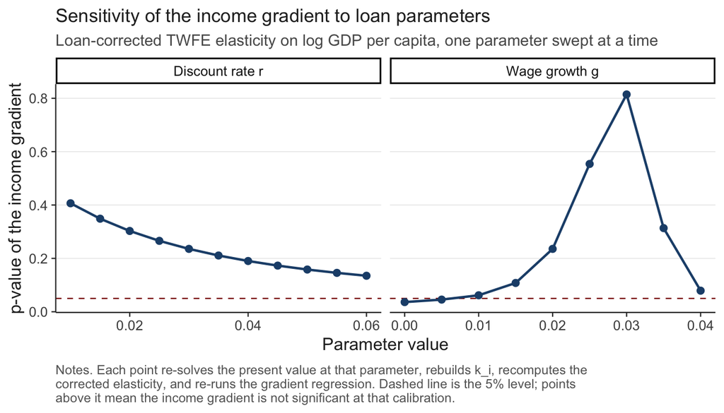

```r
ggplot(sweep_all, aes(value, p)) +
  geom_hline(yintercept = 0.05, linetype = "dashed", colour = "#8B0000", linewidth = 0.4) +
  geom_line(colour = accent, linewidth = 0.8) +
  geom_point(colour = accent, size = 2) +
  facet_wrap(~ param, scales = "free_x") +
  labs(
    x = "Parameter value",
    y = "p-value of the income gradient",
    title = "Sensitivity of the income gradient to loan parameters",
    subtitle = "Loan-corrected TWFE elasticity on log GDP per capita, one parameter swept at a time",
    caption = paste(
      "Notes. Each point re-solves the present value at that parameter, rebuilds k_i, recomputes the",
      "corrected elasticity, and re-runs the gradient regression. Dashed line is the 5% level; points",
      "above it mean the income gradient is not significant at that calibration.",
      sep = "\n"
    )
  ) +
  theme_eer()
```

## Placebo denominator: is it the loan structure or just income?

```r
## Build a placebo k that is a monotone function of income only, scaled to sit on the
## same range as the real k_i so the comparison is like-for-like. It has no threshold,
## no repayment rule, no discounting: it is income and nothing else.
placebo_df <- elas_df %>%
  filter(!is.na(k_i), !is.na(Estimate_TWFE), !is.na(log_gdp)) %>%
  mutate(
    # A pure log-income divisor with the same direction as the real k_i.
    # Because loan value rises with earnings, the effective price shock k_i falls.
    k_income_raw = log(wage_gbp),
    k_placebo    = (max(k_income_raw) - k_income_raw) /
                   (max(k_income_raw) - min(k_income_raw)) *
                   (max(k_i) - min(k_i)) + min(k_i),
    eta_placebo  = as.numeric(Estimate_TWFE) / k_placebo
  )

stopifnot(cor(placebo_df$k_placebo, placebo_df$k_income_raw) < 0)

# three gradients side by side: equal k, real heterogeneous k, placebo income-only k
g_equal   <- lm(elasticity_TWFE     ~ log_gdp, data = placebo_df)
g_real    <- lm(elasticity_new_TWFE ~ log_gdp, data = placebo_df)
g_placebo <- lm(eta_placebo         ~ log_gdp, data = placebo_df)

## HC1 robust SEs, same three models, same point estimates.
placebo_summary <- bind_rows(
  robust_tidy(g_equal)   %>% filter(term == "log_gdp") %>% mutate(denominator = "Equal k (common price change)"),
  robust_tidy(g_real)    %>% filter(term == "log_gdp") %>% mutate(denominator = "Real k_i (loan-adjusted)"),
  robust_tidy(g_placebo) %>% filter(term == "log_gdp") %>% mutate(denominator = "Placebo k (income only)")
) %>%
  transmute(denominator,
            slope    = round(estimate, 3),
            conf.low = round(conf.low, 3),
            conf.high= round(conf.high, 3),
            p        = round(p.value, 3),
            significant_5pct = p.value < 0.05)

placebo_summary
```

| denominator | slope | conf.low | conf.high | p | significant_5pct |
| --- | --- | --- | --- | --- | --- |
| Equal k (common price change) | 1.110 | 0.537 | 1.684 | 0.001 | TRUE |
| Real k_i (loan-adjusted) | -0.364 | -0.983 | 0.255 | 0.236 | FALSE |
| Placebo k (income only) | -0.274 | -0.411 | -0.137 | 0.000 | TRUE |

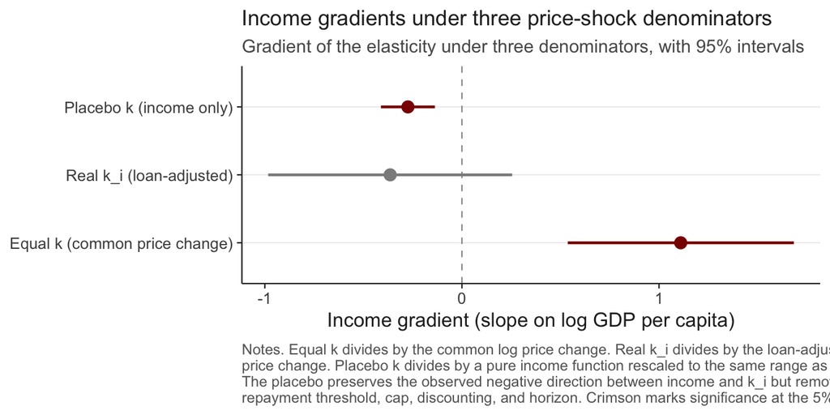

```r
placebo_summary %>%
  mutate(denominator = factor(denominator,
           levels = c("Equal k (common price change)",
                      "Real k_i (loan-adjusted)",
                      "Placebo k (income only)"))) %>%
  ggplot(aes(slope, denominator)) +
  geom_vline(xintercept = 0, linetype = "dashed", colour = "grey60", linewidth = 0.4) +
  geom_pointrange(aes(xmin = conf.low, xmax = conf.high, colour = significant_5pct),
                  linewidth = 0.8, size = 0.6) +
  scale_colour_manual(values = c(`TRUE` = "#8B0000", `FALSE` = "grey55"), guide = "none") +
  labs(
    x = "Income gradient (slope on log GDP per capita)",
    y = NULL,
    title = "Income gradients under three price-shock denominators",
    subtitle = "Gradient of the elasticity under three denominators, with 95% intervals",
    caption = paste(
      "Notes. Equal k divides by the common log price change. Real k_i divides by the loan-adjusted",
      "price change. Placebo k divides by a pure income function rescaled to the same range as k_i.",
      "The placebo preserves the observed negative direction between income and k_i but removes the",
      "repayment threshold, cap, discounting, and horizon. Crimson marks significance at the 5% level.",
      sep = "\n"
    )
  ) +
  theme_eer()
```

The equal-$k$ benchmark has a positive income gradient. With the audited 2022 data vintage, the real loan-adjusted denominator produces a small, statistically insignificant slope, while the direction-correct placebo produces a negative, statistically significant slope. The comparison shows that an arbitrary monotone income rescaling does not reproduce the near-zero gradient, although it remains a diagnostic rather than a separate causal test.

# Other interesting correlations

```r
# Reuse the single WB frame already pulled above (elas_df carries the basket).
wb_vars <- c("gdp_ppp_pc", "gini", "youth_unemp",
             "educ_spend_gdp", "tertiary_enroll", "net_migration")

# elas_df renamed gdp_ppp_pc to GDP_PPP, so map that back for the GDP column
dat <- elas_df %>% rename(gdp_ppp_pc = GDP_PPP)

min_n <- 8   # minimum complete cases to include a model

models_new <- list()
kept_vars  <- c()

for (v in wb_vars) {
  dsub <- dat %>%
    select(elasticity_new_TWFE, all_of(v)) %>%
    filter(complete.cases(.))

  if (nrow(dsub) < min_n) next                  # too few observations
  if (sd(dsub[[v]], na.rm = TRUE) == 0) next     # no variation in regressor

  models_new[[v]] <- lm(reformulate(v, response = "elasticity_new_TWFE"),
                        data = dsub)
  kept_vars <- c(kept_vars, v)
}

print(kept_vars)
```

```
## [1] "gdp_ppp_pc"      "gini"            "youth_unemp"     "educ_spend_gdp"
## [5] "tertiary_enroll" "net_migration"
```

```r
stargazer(models_new, type = "text",
          se = lapply(models_new, robust_se),
          p = lapply(models_new, robust_p),
          notes = "HC1 robust standard errors in parentheses.")
```

```
##
## =========================================================================================================================================
##                                                                      Dependent variable:
##                     ---------------------------------------------------------------------------------------------------------------------
##                                                                               v
##                            (1)                (2)                (3)                  (4)                  (5)                (6)
## -----------------------------------------------------------------------------------------------------------------------------------------
## gdp_ppp_pc               -0.00000
##                         (0.00000)
##
## gini                                         0.022
##                                             (0.026)
##
## youth_unemp                                                     0.012
##                                                                (0.010)
##
## educ_spend_gdp                                                                     -0.224***
##                                                                                     (0.078)
##
## tertiary_enroll                                                                                         -0.00005
##                                                                                                          (0.004)
##
## net_migration                                                                                                               0.00000
##                                                                                                                            (0.00000)
##
## Constant                 -0.505**            -1.396           -0.868***              0.412              -0.667**           -0.682***
##                          (0.226)            (0.821)            (0.213)              (0.373)              (0.314)            (0.102)
##
## -----------------------------------------------------------------------------------------------------------------------------------------
## Observations                25                 24                 25                  24                   25                  25
## R2                        0.024              0.046              0.041                0.298               0.00001             0.002
## Adjusted R2               -0.018             0.003             -0.0003               0.266               -0.043              -0.041
## Residual Std. Error  0.403 (df = 23)    0.393 (df = 22)    0.399 (df = 23)      0.349 (df = 22)      0.408 (df = 23)    0.407 (df = 23)
## F Statistic         0.574 (df = 1; 23) 1.058 (df = 1; 22) 0.992 (df = 1; 23) 9.322*** (df = 1; 22) 0.0002 (df = 1; 23) 0.051 (df = 1; 23)
## =========================================================================================================================================
## Note:                                                                                                         *p<0.1; **p<0.05; ***p<0.01
##                                                                                                HC1 robust standard errors in parentheses.
```

```r
library(broom)

# readable labels for the six indicators
nice_names <- c(
  gdp_ppp_pc      = "GDP per capita (PPP)",
  gini            = "Gini",
  youth_unemp     = "Youth unemployment",
  educ_spend_gdp  = "Education spending (% GDP)",
  tertiary_enroll = "Tertiary enrollment",
  net_migration   = "Net migration"
)

wb_vars <- names(nice_names)

# Refit each bivariate model on standardized variables so slopes are comparable,
# carrying the R-squared, sample size, and HC1 inference.

std_df <- bind_rows(lapply(wb_vars, function(v) {

  d <- dat %>%
    select(y = elasticity_new_TWFE, x = all_of(v)) %>%
    filter(complete.cases(.))

  if (nrow(d) < 8 || sd(d$x) == 0) return(NULL)

  d <- d %>%
    mutate(
      x = as.numeric(scale(x)),
      y = as.numeric(scale(y))
    )

  m <- lm(y ~ x, data = d)

  robust_tidy(m) %>%
    filter(term == "x") %>%
    mutate(
      variable = nice_names[v],
      r2 = summary(m)$r.squared,
      n = nrow(d)
    )
})) %>%
  mutate(
    p_hc1 = p.value,
    sig_hc1 = p_hc1 < 0.05,
    p_label = if_else(
      p_hc1 < 0.001,
      "p < .001",
      sprintf("p = %.3f", p_hc1)
    ),
    variable = factor(
      variable,
      levels = variable[order(estimate)]
    )
  )

std_df %>%
  select(
    variable,
    estimate,
    std.error,
    conf.low,
    conf.high,
    p_hc1,
    r2,
    n
  )
```

| variable | estimate | std.error | conf.low | conf.high | p_hc1 | r2 | n |
| --- | --- | --- | --- | --- | --- | --- | --- |
| GDP per capita (PPP) | -0.156078528 | 0.2018511 | -0.5736393 | 0.2614822 | 0.447257319 | 2.436051e-02 | 25 |
| Gini | 0.214176721 | 0.2486375 | -0.3014658 | 0.7298192 | 0.398308579 | 4.587167e-02 | 24 |
| Youth unemployment | 0.203304776 | 0.1713329 | -0.1511243 | 0.5577338 | 0.247495398 | 4.133283e-02 | 25 |
| Education spending (% GDP) | -0.545536200 | 0.1907222 | -0.9410697 | -0.1500027 | 0.009094547 | 2.976097e-01 | 24 |
| Tertiary enrollment | -0.003026126 | 0.2620460 | -0.5451097 | 0.5390574 | 0.990885763 | 9.157441e-06 | 25 |
| Net migration | 0.047219816 | 0.1063753 | -0.1728342 | 0.2672738 | 0.661264162 | 2.229711e-03 | 25 |

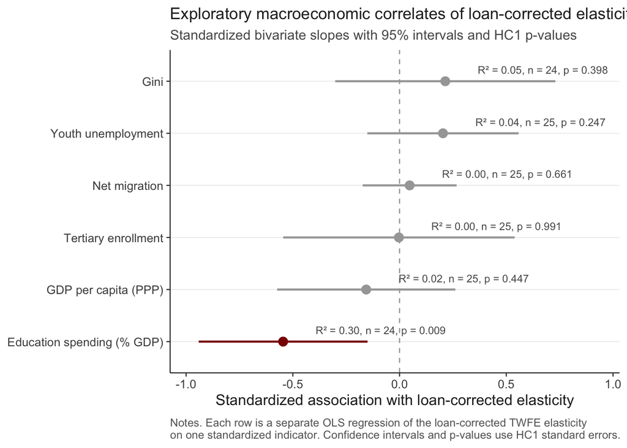

```r
ggplot(std_df, aes(estimate, variable)) +
  geom_vline(
    xintercept = 0,
    linetype = "dashed",
    colour = "grey60",
    linewidth = 0.4
  ) +
  geom_pointrange(
    aes(
      xmin = conf.low,
      xmax = conf.high,
      colour = sig_hc1
    ),
    linewidth = 0.8,
    size = 0.6
  ) +
  geom_text(
    aes(
      label = sprintf(
        "R² = %.2f, n = %d, %s",
        r2,
        n,
        p_label
      )
    ),
    hjust = -0.25,
    vjust = -1,
    size = 3,
    colour = "grey35"
  ) +
  scale_colour_manual(
    values = c(
      `TRUE` = "#8B0000",
      `FALSE` = "grey65"
    ),
    guide = "none"
  ) +
  scale_x_continuous(
    expand = expansion(mult = c(0.08, 0.18))
  ) +
  labs(
    x = "Standardized association with loan-corrected elasticity",
    y = NULL,
    title = "Exploratory macroeconomic correlates of loan-corrected elasticity",
    subtitle = "Standardized bivariate slopes with 95% intervals and HC1 p-values",
    caption = paste(
      "Notes. Each row is a separate OLS regression of the loan-corrected TWFE elasticity",
      "on one standardized indicator. Confidence intervals and p-values use HC1 standard errors.",
      sep = "\n"
    )
  ) +
  theme_eer()
```

# Publication figures

## Figure 2. Income gradient in the loan-corrected elasticity

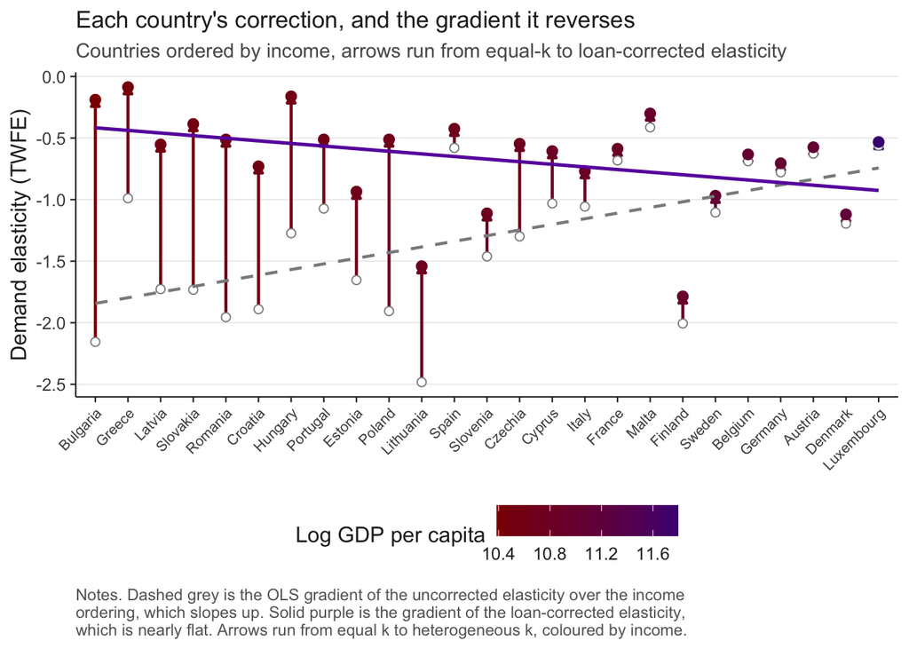

```r
shift_df <- elas_df %>%
  select(Country, log_gdp, old = elasticity_TWFE, new = elasticity_new_TWFE) %>%
  filter(!is.na(old), !is.na(new), !is.na(log_gdp)) %>%
  arrange(log_gdp) %>%
  mutate(x = row_number())          # one distinct column per country, ordered by income

ggplot(shift_df, aes(x = x)) +

 # each country's shift, arrow running from the old to the corrected elasticity,
  # coloured by income so the columns carry the GDP dimension
  geom_segment(aes(xend = x, y = old, yend = new, colour = log_gdp),
               arrow = arrow(length = unit(0.06, "inches"), type = "closed"),
               linewidth = 0.8) +

  geom_point(aes(y = old), shape = 21, fill = "white", colour = "grey55", size = 2) +
  geom_point(aes(y = new, colour = log_gdp), size = 2.4) +

  # the two gradients laid over the ordered columns
  geom_smooth(aes(y = old), method = "lm", se = FALSE,
              colour = "grey55", linetype = "dashed", linewidth = 0.8) +
  geom_smooth(aes(y = new), method = "lm", se = FALSE,
              colour = "#6A0DAD", linewidth = 0.9) +

  scale_colour_gradient(low = "#8B0000", high = "#4B0082",
                        name = "Log GDP per capita") +
  scale_x_continuous(breaks = shift_df$x, labels = shift_df$Country,
                     expand = expansion(add = 0.6)) +

  labs(
    x = NULL,
    y = "Demand elasticity (TWFE)",
    title = "Each country's correction, and the gradient it reverses",
    subtitle = "Countries ordered by income, arrows run from equal-k to loan-corrected elasticity",
caption = paste(
      "Notes. Dashed grey is the OLS gradient of the uncorrected elasticity over the income",
      "ordering, which slopes up. Solid purple is the gradient of the loan-corrected elasticity,",
      "which is nearly flat. Arrows run from equal k to heterogeneous k, coloured by income.",
      sep = "\n"
    )
    ) +
  theme_eer() +
  theme(axis.text.x = element_text(angle = 45, hjust = 1, size = 8))
```

## Figure 3. Income-gradient slope across specifications

A coefficient figure. Each row is the slope on log GDP per capita from one elasticity specification, with a 95% interval. It shows whether the gradient survives the move from equal to heterogeneous k and across the fixed-effects designs.

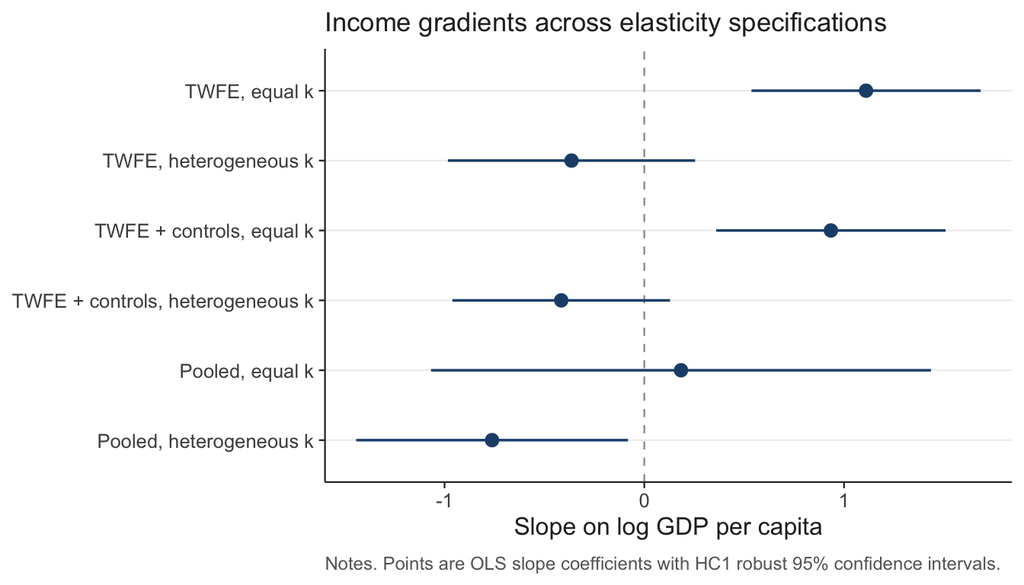

```r
## HC1 robust CIs, so this plot matches the robust SEs stargazer reports
## above rather than showing classical intervals next to robust tables.
slope_df <- bind_rows(
  robust_tidy(reg_old_TWFE)     %>% mutate(model = "TWFE, equal k"),
  robust_tidy(reg_new_TWFE)     %>% mutate(model = "TWFE, heterogeneous k"),
  robust_tidy(reg_old_controls) %>% mutate(model = "TWFE + controls, equal k"),
  robust_tidy(reg_new_controls) %>% mutate(model = "TWFE + controls, heterogeneous k"),
  robust_tidy(reg_old_pooled)   %>% mutate(model = "Pooled, equal k"),
  robust_tidy(reg_new_pooled)   %>% mutate(model = "Pooled, heterogeneous k")
) %>%
  filter(term == "log_gdp") %>%
  mutate(model = factor(model, levels = rev(model)))

ggplot(slope_df, aes(estimate, model)) +
  geom_vline(xintercept = 0, linetype = "dashed", colour = "grey60", linewidth = 0.4) +
  geom_pointrange(aes(xmin = conf.low, xmax = conf.high),
                  colour = accent, linewidth = 0.6, size = 0.5) +
  labs(
    x = "Slope on log GDP per capita",
    y = NULL,
    title = "Income gradients across elasticity specifications",
    caption = "Notes. Points are OLS slope coefficients with HC1 robust 95% confidence intervals."
  ) +
  theme_eer()
```

## Figure 4. How much loan loss amplifies the effective price increase

The common-fee benchmark raises log price by `k_common`. Losing a loan whose present value is below its principal makes the effective increase larger, especially where expected repayments are low. This ranks each country by its loan-adjusted price change `k_i` against the common benchmark.

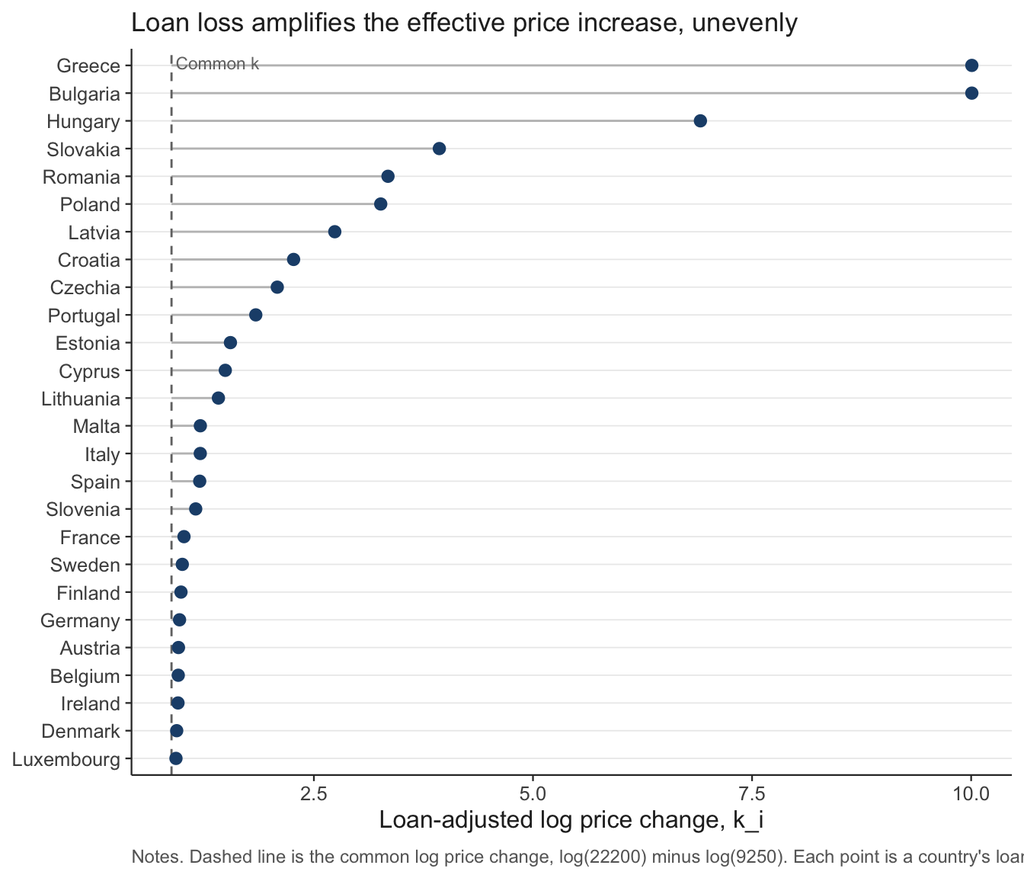

```r
k_df <- elas_df %>%
  select(Country, k_i) %>%
  filter(!is.na(k_i)) %>%
  arrange(k_i) %>%
  mutate(Country = factor(Country, levels = Country))

ggplot(k_df, aes(k_i, Country)) +
  geom_segment(aes(x = k_common, xend = k_i, y = Country, yend = Country),
               colour = "grey75", linewidth = 0.5) +
  geom_vline(xintercept = k_common, linetype = "dashed",
             colour = "grey45", linewidth = 0.5) +
  geom_point(colour = accent, size = 2.4) +
  annotate("text", x = k_common, y = Inf, label = "Common k",
           vjust = 1.6, hjust = -0.05, size = 3, colour = "grey45") +
  labs(
    x = "Loan-adjusted log price change, k_i",
    y = NULL,
    title = "Loan loss amplifies the effective price increase, unevenly",
    caption = "Notes. Dashed line is the common log price change, log(22200) minus log(9250). Each point is a country's loan-adjusted k_i."
  ) +
  theme_eer()
```